# Tugas Pertemuan 2 - MPDW

Lara Tria Novita

# Pemanggilan *Packages*

```r
#install.packages("https://cran.r-project.org/src/contrib/Archive/orcutt/orcutt_2.1.tar.gz", repos = NULL, type = "source")
```

```r
#install.packages("orcutt")
```

```r
library(dplyr)
library(TTR)
library(forecast)
library(lmtest) #digunakan untuk uji formal pendeteksian autokorelasi
library(orcutt) #untuk membuat model regresi Cochrane-Orcutt
library(HoRM) #untuk membuat model regresi Hildreth-Lu
```

# Input Data

```r
year <- 1975:2014
sales <- c(11.7,12.0,12.3,12.8,13.1,13.6,13.9,14.4,14.7,15.3,15.5,15.8,16.1,16.6,16.9,16.7,16.9,17.4,17.6,17.9,18.0,17.9,18.0,18.2,18.2,18.3,18.6,19.2,19.3,19.5,19.2,19.3,19.5,20.0,20.0,19.9,19.8,19.9,20.2,21.0)
advertising <- c(9.4,9.6,10.0,10.4,10.8,10.9,11.7,12.2,12.5,12.9,13.0,13.2,13.8,14.2,14.6,14.4,15.0,15.4,15.7,15.9,15.9,16.0,16.3,16.2,16.8,17.3,17.6,18.1,18.3,18.5,18.7,18.9,19.2,20.0,20.0,20.3,20.4,21.0,21.5,22.1)
dt <- cbind(year,sales,advertising)
dt <- as.data.frame(dt)
dt
```

```
##    year sales advertising
## 1  1975  11.7         9.4
## 2  1976  12.0         9.6
## 3  1977  12.3        10.0
## 4  1978  12.8        10.4
## 5  1979  13.1        10.8
## 6  1980  13.6        10.9
## 7  1981  13.9        11.7
## 8  1982  14.4        12.2
## 9  1983  14.7        12.5
## 10 1984  15.3        12.9
## 11 1985  15.5        13.0
## 12 1986  15.8        13.2
## 13 1987  16.1        13.8
## 14 1988  16.6        14.2
```

[output cut: 26 more lines]

# Eksplorasi Data

Sebelum melakukan regresi, akan diperlihatkan *plot time-series* dari advertising dan sales untuk melihat pola pergerakan sepanjang waktu.

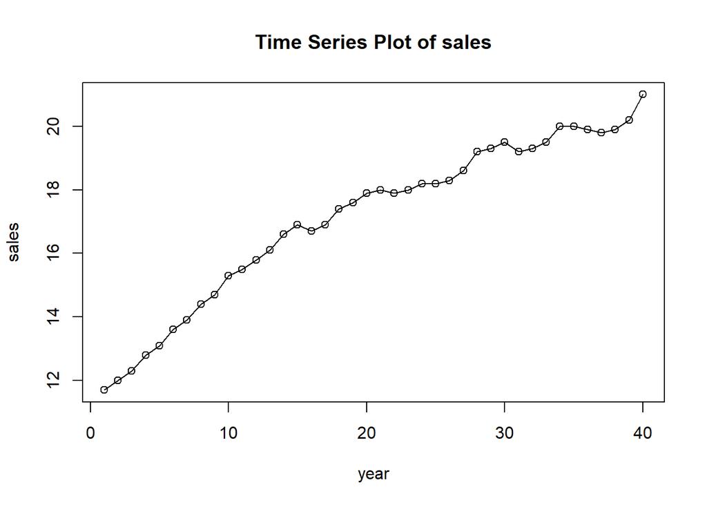

```r
#Membentuk objek time series
ts_sales<-ts(dt$sales)
ts_adv <-ts(dt$advertising,start=1975)

#Membuat plot time series
ts.plot(ts_sales, xlab="year", ylab="sales", main= "Time Series Plot of sales")
points(ts_sales)
```

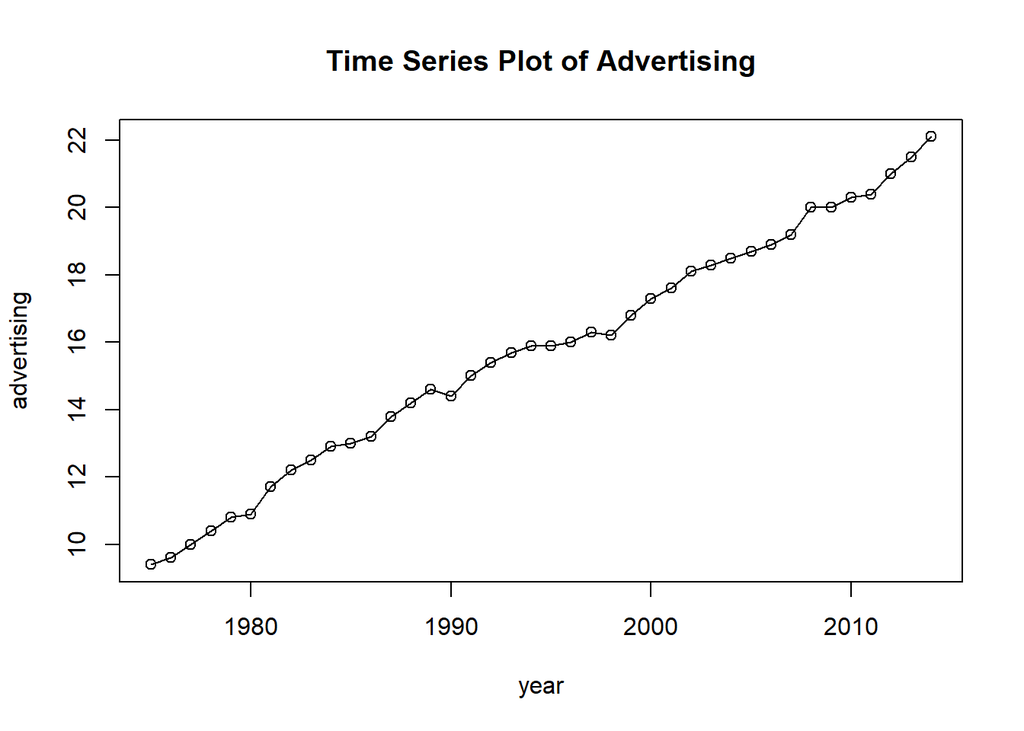

```r
ts.plot(ts_adv, xlab="year", ylab="advertising", main="Time Series Plot of Advertising")
points(ts_adv)
```

Kedua peubah menunjukkan tren yang naik secara konsisten sepanjang periode 1975-2014, dengan pola pergerakan yang sangat mirip antara Sales dan Advertising. Kemiripan tren ini mengindikasikan hubungan linear yang kuat antar kedua peubah, sekaligus berpotensi menimbulkan autokorelasi pada sisaan jika keduanya diregresikan (karena keduanya sama-sama “berjalan” mengikuti waktu).

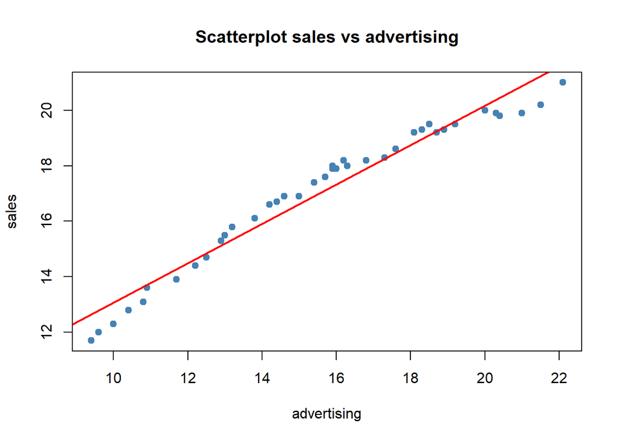

```r
#scatterplot
plot(dt$advertising,dt$sales, xlab = "advertising", ylab="sales", main = "Scatterplot sales vs advertising", pch = 19, col = "steelblue")
abline(lm(dt$sales ~ dt$advertising), col = "red", lwd = 2)
```

# Pemodelan Regresi

```r
model <- lm(sales ~ advertising, data=dt)
summary(model)
```

```
##
## Call:
## lm(formula = sales ~ advertising, data = dt)
##
## Residuals:
##      Min       1Q   Median       3Q      Max
## -1.03758 -0.40343  0.08933  0.45674  0.74036
##
## Coefficients:
##             Estimate Std. Error t value Pr(>|t|)
## (Intercept)  5.96513    0.38092   15.66   <2e-16 ***
## advertising  0.71035    0.02365   30.04   <2e-16 ***
## ---
## Signif. codes:  0 '***' 0.001 '**' 0.01 '*' 0.05 '.' 0.1 ' ' 1
##
## Residual standard error: 0.527 on 38 degrees of freedom
## Multiple R-squared:  0.9596, Adjusted R-squared:  0.9585
## F-statistic: 902.3 on 1 and 38 DF,  p-value: < 2.2e-16
```

Berdasarkan output di atas, diperoleh model regresi: Ŷt = 5.96513 + 0.71035 Xt dengan nilaiR² = 0,9596 yang berarti sekitar 95,96% keragaman sales dapat dijelaskan oleh advertising.

#Pemeriksaan Asumsi Autokorelasi

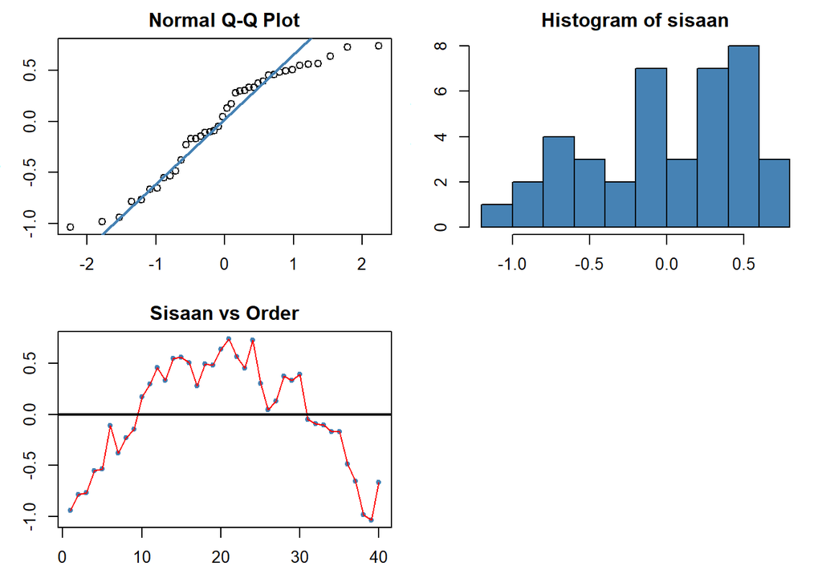

```r
#sisaan
sisaan<- residuals(model)

#Diagnostik dengan eksploratif
par(mfrow = c(2,2),mar=c(3,3,2,1))
qqnorm(sisaan)

qqline(sisaan, col = "steelblue", lwd = 2)

hist(sisaan, col = "steelblue")
plot(seq_along(sisaan), sisaan,
     col = "steelblue",
     pch = 20,
     xlab = "Order",
     ylab = "Sisaan",
     main = "Sisaan vs Order")
lines(seq_along(sisaan), sisaan, col = "red")
abline(a = 0, b = 0, lwd = 2)
```

Normal Q-Q Plot di atas menunjukkan bahwa sisaan cenderung menyebar normal, tetapi histogram dari sisaan tidak menunjukkan demikian. Selanjutnya, Plot Sisaan vs *Order* menunjukkan pola yang sangat sistematis — residual bergerombol positif dalam waktu lama kemudian bergerombol negatif dalam waktu lama pula (bukan berfluktuasi acak di sekitar nol). Ini adalah ciri khas autokorelasi positif yang kuat pada sisaan.Untuk lebih lanjut akan digunakan uji formal melihat normalitas sisaan dan plot ACF dan PACF untuk melihat apakah ada autokorelasi atau tidak.

```r
#Melihat Sisaan Menyebar Normal/Tidak
#H0: sisaan mengikuti sebaran normal
#H1: sisaan tidak mengikuti sebaran normal
shapiro.test(sisaan)
```

```
##
##  Shapiro-Wilk normality test
##
## data:  sisaan
## W = 0.93205, p-value = 0.0188
```

```r
ks.test(sisaan, "pnorm", mean=mean(sisaan), sd=sd(sisaan))
```

```
##
##  Asymptotic one-sample Kolmogorov-Smirnov test
##
## data:  sisaan
## D = 0.15458, p-value = 0.2948
## alternative hypothesis: two-sided
```

Berdasarkan uji formal Saphiro-Wilk didapatkan nilai *p-value* < $\alpha$ (5%). Artinya, cukup bukti untuk menyatakan sisaan tidak berdistribusi normal.

Kolmogorov-Smirnov didapatkan nilai *p-value* > $\alpha$ (5%). Artinya, cukup bukti untuk menyatakan sisaan berdistribusi normal.

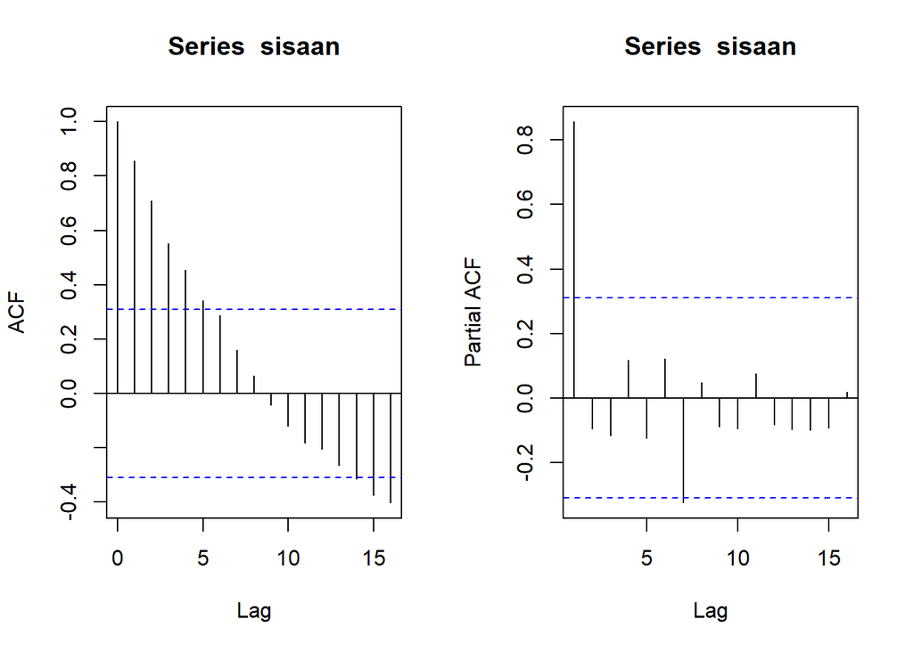

```r
#ACF dan PACF identifikasi autokorelasi
par(mfrow = c(1,2))
acf(sisaan)
pacf(sisaan)
```

Grafik ACF Menunjukkan pola tails off (menurun secara perlahan) dengan banyak lag signifikan. Ini menandakan adanya autokorelasi positif yang kuat pada sisaan (asumsi kebebasan sisaan dilanggar). Grafik PACF Menunjukkan pola cuts off (terputus drastis) tepat setelah lag 1.

```r
#Deteksi autokorelasi dengan uji-Durbin Watson
#H0: tidak ada autokorelasi
#H1: ada autokorelasi
dwtest(model)
```

```
##
##  Durbin-Watson test
##
## data:  model
## DW = 0.16204, p-value < 2.2e-16
## alternative hypothesis: true autocorrelation is greater than 0
```

Nilai statistik Durbin-Watson (DW) = 0.16204 dengan p-value < 0,0001. Untuk n = 40 dan k = 1 peubah penjelas pada taraf nyata 5%, nilai kritis Durbin-Watson adalah dL ≈ 1.44 dan dU ≈ 1.54. DW = 0.16204 < dL = 1.44

maka H0 ditolak, yang berarti terdapat autokorelasi (autokorelasi positif) pada sisaan model regresi. Hasil ini konsisten dengan pola yang terlihat pada plot sisaan sebelumnya. Oleh karena itu, diperlukan penangan autokorelasi. Penanganan yang akan digunakan menggunakan dua metode, yaitu Cochrane-Orcutt dan Hildret-Lu.

# Penanganan Autokorelasi

## Metode Cochrane-Orcutt

Penanganan autokorelasi dilakukan dengan metode Cochrane-Orcutt, yaitu melakukan transformasi generalized least squares (GLS) secara iteratif hingga diperoleh nilai koefisien autokorelasi (ρ) yang konvergen.

```r
#Penanganan Autokorelasi Cochrane-Orcutt
modelCO<-cochrane.orcutt(model)
modelCO
```

```
## Cochrane-orcutt estimation for first order autocorrelation
##
## Call:
## lm(formula = sales ~ advertising, data = dt)
##
##  number of interaction: 39
##  rho 0.903123
##
## Durbin-Watson statistic
## (original):    0.16204 , p-value: 8.935e-20
## (transformed): 1.93925 , p-value: 3.78e-01
##
##  coefficients:
## (Intercept) advertising
##   10.252375    0.488489
```

Hasil keluaran model setelah dilakukan penanganan adalah sebagai berikut.
$$y_i= 10.252375
+ 0.488489x_t$$
Hasil juga menunjukkan bahwa nilai DW dan p-value meningkat menjadi $1.93925$ dan $0.378$. Nilai DW sudah berada pada rentang DU < DW < 4-DU. Hal tersebut juga didukung dengan nilai *p-value* > 0.05, artinya belum cukup bukti menyatakan bahwa sisaan terdapat autokorelasi pada taraf nyata 5%. Untuk nilai $ρ ̂$ optimum yang digunakan adalah $0.9031233$. Nilai tersebut dapat diketahui dengan *syntax* berikut.

```r
#Rho optimum
rho<- modelCO$rho
rho
```

```
## [1] 0.9031233
```

### Plot sisaan setelah Penanganan

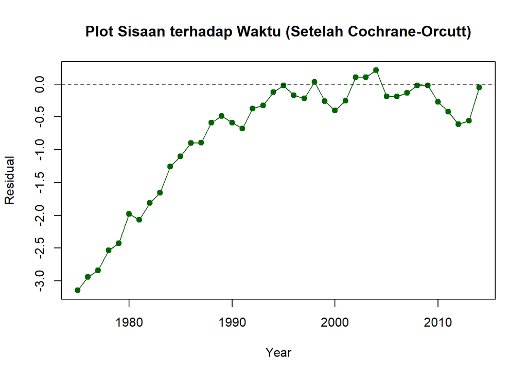

```r
sisaan.co <- dt$sales - (modelCO$coefficients[1] +
                            modelCO$coefficients[2] * dt$advertising)

plot(year, sisaan.co, type = "o", pch = 19, col = "darkgreen",
     xlab = "Year", ylab = "Residual",
     main = "Plot Sisaan terhadap Waktu (Setelah Cochrane-Orcutt)")
abline(h = 0, lty = 2)
```

## Metode Hildreth-Lu

Penanganan kedua adalah menggunakan metode Hildreth-Lu. Metode ini akan mencari nilai SSE terkecil.

```r
library(HoRM)

# ambil y dan x (satu prediktor saja)
y <- dt$sales
x <- dt$advertising

# grid search rho 0–0.9
r <- seq(0, 0.9, by = 0.1)
tab <- data.frame(
  rho = r,
  SSE = sapply(r, function(rr) deviance(hildreth.lu(y, x, rr)))
)

tab            # tabel rho vs SSE
```

```
##    rho      SSE
## 1  0.0 9.561851
## 2  0.1 7.845710
## 3  0.2 6.330287
## 4  0.3 5.015381
## 5  0.4 3.900668
## 6  0.5 2.985599
## 7  0.6 2.269173
## 8  0.7 1.749430
## 9  0.8 1.422573
## 10 0.9 1.291395
```

```r
rho_hat <- tab$rho[which.min(tab$SSE)]   # rho terbaik
fit_hl  <- hildreth.lu(y, x, rho_hat)    # model final
summary(fit_hl)
```

```
##
## Call:
## lm(formula = y ~ x)
##
## Residuals:
##     Min      1Q  Median      3Q     Max
## -0.3749 -0.1461  0.0148  0.1057  0.4496
##
## Coefficients:
##             Estimate Std. Error t value Pr(>|t|)
## (Intercept)  1.01310    0.14198   7.135 1.87e-08 ***
## x            0.49358    0.07379   6.689 7.38e-08 ***
## ---
## Signif. codes:  0 '***' 0.001 '**' 0.01 '*' 0.05 '.' 0.1 ' ' 1
##
## Residual standard error: 0.1868 on 37 degrees of freedom
## Multiple R-squared:  0.5474, Adjusted R-squared:  0.5351
## F-statistic: 44.74 on 1 and 37 DF,  p-value: 7.382e-08
```

```r
#Penanganan Autokorelasi Hildreth lu
# Hildreth-Lu
hildreth.lu.func<- function(r, model){
  x <- model.matrix(model)[,-1]
  y <- model.response(model.frame(model))
  n <- length(y)
  t <- 2:n
  y <- y[t]-r*y[t-1]
  x <- x[t]-r*x[t-1]

  return(lm(y~x))
}

#Pencariab rho yang meminimumkan SSE
r <- c(seq(0.1,0.9, by= 0.1))
tab <- data.frame("rho" = r, "SSE" = sapply(r, function(i){deviance(hildreth.lu.func(i, model))}))
round(tab, 4)
```

```
##   rho    SSE
## 1 0.1 7.8457
## 2 0.2 6.3303
## 3 0.3 5.0154
## 4 0.4 3.9007
## 5 0.5 2.9856
## 6 0.6 2.2692
## 7 0.7 1.7494
## 8 0.8 1.4226
## 9 0.9 1.2914
```

Pertama-tama akan dicari di mana kira-kira $ρ$ yang menghasilkan SSE minimum. Pada hasil di atas terlihat $ρ$ minimum ketika 0,9. Namun, hasil tersebut masih kurang teliti sehingga akan dicari kembali $ρ$ yang lebih optimum dengan ketelitian yang lebih. Jika sebelumnya jarak antar $ρ$ yang dicari adalah 0.1, kali ini jarak antar $ρ$ adalah 0.001 dan dilakukan pada selang 0.7 sampai dengan 1.0.

```r
#Rho optimal di sekitar 0.4
rOpt <- seq(0.7,1.0, by= 0.001)
tabOpt <- data.frame("rho" = rOpt, "SSE" = sapply(rOpt, function(i){deviance(hildreth.lu.func(i, model))}))
head(tabOpt[order(tabOpt$SSE),])
```

```
##       rho      SSE
## 204 0.903 1.291226
## 205 0.904 1.291239
## 203 0.902 1.291248
## 206 0.905 1.291289
## 202 0.901 1.291304
## 207 0.906 1.291375
```

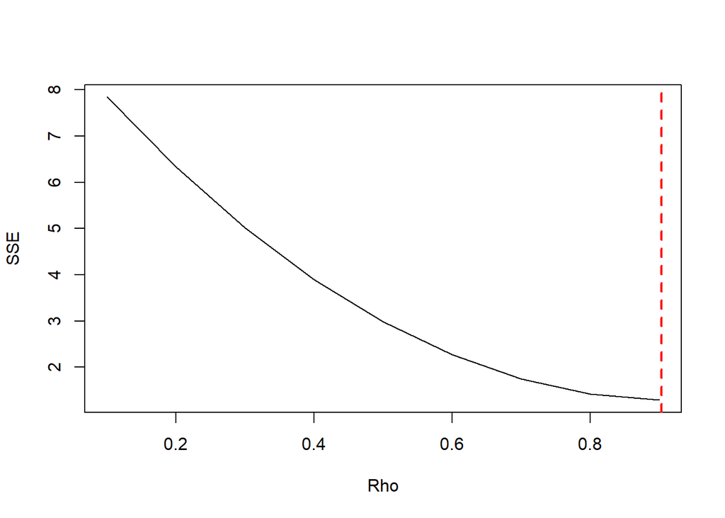

```r
#Grafik SSE optimum
par(mfrow = c(1,1))
plot(tab$SSE ~ tab$rho , type = "l", xlab = "Rho", ylab = "SSE")
abline(v = tabOpt[tabOpt$SSE==min(tabOpt$SSE),"rho"], lty = 2, col="red",lwd=2)
text(x=0.341, y=0.2397500, labels = "rho=0.341", cex = 0.8)
```

Perhitungan yang dilakukan aplikasi `R` menunjukkan bahwa nilai $ρ$ optimum, yaitu saat SSE terkecil terdapat pada nilai $ρ=0.903$. Hal tersebut juga ditunjukkan pada plot. Selanjutnya, model dapat didapatkan dengan mengevaluasi nilai $ρ$ ke dalam fungsi `hildreth.lu.func`, serta dilanjutkan dengan pengujian autokorelasi dengan uji Durbin-Watson. Namun, setelah pengecekan tersebut tidak lupa koefisien regresi tersebut digunakan untuk transformasi balik. Persamaan hasil transformasi itulah yang menjadi persamaan sesungguhnya.

```r
#Model terbaik
modelHL <- hildreth.lu.func(0.903, model)
summary(modelHL)
```

```
##
## Call:
## lm(formula = y ~ x)
##
## Residuals:
##      Min       1Q   Median       3Q      Max
## -0.37720 -0.14949  0.01266  0.10464  0.45301
##
## Coefficients:
##             Estimate Std. Error t value Pr(>|t|)
## (Intercept)  0.99401    0.14144   7.028 2.60e-08 ***
## x            0.48869    0.07536   6.485 1.39e-07 ***
## ---
## Signif. codes:  0 '***' 0.001 '**' 0.01 '*' 0.05 '.' 0.1 ' ' 1
##
## Residual standard error: 0.1868 on 37 degrees of freedom
## Multiple R-squared:  0.532,  Adjusted R-squared:  0.5193
## F-statistic: 42.05 on 1 and 37 DF,  p-value: 1.39e-07
```

```r
#Transformasi Balik
cat("y = ", coef(modelHL)[1]/(1-0.903), "+", coef(modelHL)[2],"x", sep = "")
```

```
## y = 10.24749+0.4886925x
```

Setelah dilakukan tranformasi balik, didapatkan model dengan metode Hildreth-Lu sebagai berikut.
$$y_i=10.24749+0.4886925xx_t$$

```r
#Deteksi autokorelasi
dwtest(modelHL)
```

```
##
##  Durbin-Watson test
##
## data:  modelHL
## DW = 1.9393, p-value = 0.378
## alternative hypothesis: true autocorrelation is greater than 0
```

Hasil uji Durbin-Watson juga menunjukkan bawah nilai DW sebesar $1.9393$ berada pada selang daerah tidak ada autokorelasi, yaitu pada rentang DU < DW < 4-DU. Hal tersebut juga didukung oleh *p-value* sebesar $0.378$, di mana *p-value* > $\alpha$=5%. Artinya tak tolak $H_0$ atau belum cukup bukti menyatakan bahwa ada autokorelasi dalam data dengan metode Hildreth-Lu pada taraf nyata 5%.

# Simpulan

1. Model regresi awal (OLS) Sales terhadap Advertising memiliki R² = 0.9596, namun uji Durbin-Watson menunjukkan autokorelasi positif yang sangat kuat pada sisaan (DW = 0.1620 << dL = 1.44).
2. Penanganan dengan Cochrane-Orcutt dan Hildreth-Lu sama-sama berhasil menghilangkan autokorelasi, dengan DW baru sekitar 1.94 pada kedua metode.
3. Model akhir yang direkomendasikan (mis. dari Cochrane-Orcutt): Ŷt = 10.2523 + 0.4885 Xt, ρ̂ = 0.9031